# Demo: Analyzing Categorical Columns

### 1. Import Packages and Connect to the CAS Server

Visit the documentation for the SWAT [(SAS Scripting Wrapper for Analytics Transfer)](https://sassoftware.github.io/python-swat/index.html) package.

```python
## Import packages
import swat
import pandas as pd
import matplotlib.pyplot as plt
plt.style.use('seaborn')

## Set options
pd.set_option('display.max_columns', None)

## Connect to CAS
conn = swat.CAS('server.demo.sas.com', 30571, 'student', 'Metadata0', name = 'py03d03')

## Function to load the loans_raw.sashdat file into memory if necessary
def loadLoans():
    conn.loadTable(path ='loans_raw.sashdat', caslib = 'PIVY',
                   casOut = {'name' : 'loans_raw',
                            'caslib' : 'casuser',
                            'promote' : True})
```

### 2. Explore Available CAS Tables

a. Use the tableInfo action to view all available in-memory tables in the **Casuser** caslib. If the **LOANS_RAW** CAS table is not available, uncomment the loadLoans function and execute the cell.

```python
#loadLoans()
conn.tableInfo(caslib = 'casuser')
```

**§ TableInfo**

|  | Name | Label | Rows | Columns | IndexedColumns | Encoding | CreateTimeFormatted | ModTimeFormatted | AccessTimeFormatted | JavaCharSet | CreateTime | ModTime | AccessTime | Global | Repeated | View | MultiPart | SourceName | SourceCaslib | Compressed | Creator | Modifier | SourceModTimeFormatted | SourceModTime |
| --- | --- | --- | --- | --- | --- | --- | --- | --- | --- | --- | --- | --- | --- | --- | --- | --- | --- | --- | --- | --- | --- | --- | --- | --- |
| 0 | CARS | 2004 Car Data | 428 | 15 | 0 | utf-8 | 2022-03-17T19:30:27+00:00 | 2022-03-17T19:30:27+00:00 | 2022-03-17T20:27:32+00:00 | UTF8 | 1.963165e+09 | 1.963165e+09 | 1.963168e+09 | 1 | 0 | 0 | 0 | cars.sas7bdat | PIVY | 0 | student |  | 2021-12-17T18:43:57+00:00 | 1.955386e+09 |
| 1 | LOANS_RAW |  | 16311047 | 20 | 0 | utf-8 | 2022-03-17T20:28:57+00:00 | 2022-03-17T20:28:57+00:00 | 2022-03-17T20:31:55+00:00 | UTF8 | 1.963168e+09 | 1.963168e+09 | 1.963168e+09 | 1 | 0 | 0 | 0 | loans_raw.sashdat | PIVY | 0 | student |  | 2021-12-17T18:40:14+00:00 | 1.955386e+09 |

elapsed 0.00266s · user 0.00131s · sys 0.000736s · mem 0.826MB

b. Reference the **LOANS_RAW** CAS table using the CASTable method, and preview the table using the head method.

```python
tbl = conn.CASTable('loans_raw', caslib = 'casuser')
tbl.head()
```

Selected Rows from Table LOANS_RAW

|  | ID | AccNumber | Year | Month | Day | CurrentDate | SalaryGroup | Age | Salary | EmpLength | Category | Amount | InterestRate | LoanLength | LoanGrade | LoanStatus | LastPurchase | Cancelled | CancelledReason | Promotion |
| --- | --- | --- | --- | --- | --- | --- | --- | --- | --- | --- | --- | --- | --- | --- | --- | --- | --- | --- | --- | --- |
| 0 | I-00006307127350009978 | CL3246299535967411-4949000 | 2022.0 | 7.0 | 13.0 | 31DEC2022 | Less than $50,000 | 30.0 | 9128.0 | 11.0 | Car Loan | 14173.66 | 4.26 | 5.0 | C | Current | NaT | 0.0 |  | 0.0 |
| 1 | I-00006307127350009978 | PKEO-1058-5781-4683-1737 | 2020.0 | 7.0 | 16.0 | 31DEC2022 | Less than $50,000 | 30.0 | 9128.0 | 11.0 | Credit Card | 2883.72 | 16.78 | 999999.0 | C | Late | 2022-12-16 | 0.0 |  | 0.0 |
| 2 | I-00006307127350009978 | M9708726115059108-92217000 | 2016.0 | 3.0 | 15.0 | 31DEC2022 | Less than $50,000 | 30.0 | 9128.0 | 11.0 | Mortgage | 13642.37 | 5.00 | 30.0 | C | Current | NaT | 0.0 |  | 0.0 |
| 3 | G-00005046456530690193 | PKEO-0775-3531-9166-5132 | 2020.0 | 2.0 | 10.0 | 31DEC2022 | $50,001 - $100,000 | 46.0 | 92000.0 | 10.0 | Credit Card | 10957.10 | 13.62 | 999999.0 | B | Current | 2022-03-19 | 0.0 |  | 0.0 |
| 4 | C-00006496445944067091 | PKEO-0832-4079-2767-3394 | 2013.0 | 5.0 | 5.0 | 31DEC2022 | Less than $50,000 | 28.0 | 17029.0 | 14.0 | Credit Card | 5257.41 | 21.83 | 999999.0 | B | Current | 2014-08-07 | 0.0 |  | 0.0 |

### 3. Frequency Distribution Using the value_counts Method

a. Use the value_counts method on the **Category** column to view frequency values of each category, and store the results in the variable **vc_df**. In the value_counts method, use the normalize equals *True* option. Display the **vc_df** object type and value of the object. The CAS server summarizes the data and returns a **Series** to the client.

```python
vc_df = (tbl
         .Category
         .value_counts(normalize = True))

## Display the object type and view the results
display(type(vc_df), vc_df)
```

```
pandas.core.series.Series
```

```
Credit Card         0.529379
Consolidation       0.085145
Mortgage            0.076226
Small Business      0.069785
Car Loan            0.069763
Home Improvement    0.059881
Education           0.039946
Medical             0.029943
Personal            0.010037
Major Purchase      0.009977
Vacation            0.009956
Weddings            0.004992
Moving Expenses     0.004971
dtype: float64
```

b. With a **Series** object returned from CAS to the client, you can use the traditional Pandas plot method to visualize the summarized results.

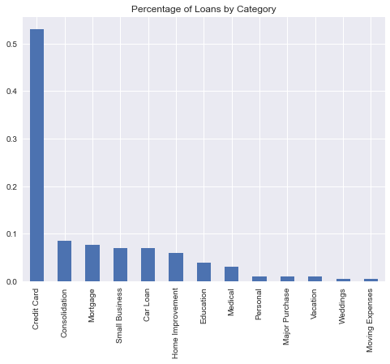

```python
vc_df.plot(kind = 'bar', figsize = (8,6), title = 'Percentage of Loans by Category');
```

### 4. Frequency Distribution Using the freq Action

a. You can use the [simple.freq](https://documentation.sas.com/doc/en/pgmsascdc/v_018/casanpg/cas-simple-freq.htm) action to obtain the frequency distribution of multiple columns. The freq action returns a **CASResults** object with a single **SASDataFrame**. Here, the **Category** and **LoanGrade** columns are specified in the inputs parameter.

```python
freq_results = tbl.freq(inputs = ['Category','LoanGrade'])
freq_results
```

**§ Frequency**

Frequency for LOANS_RAW

|  | Column | CharVar | FmtVar | Level | Frequency |
| --- | --- | --- | --- | --- | --- |
| 0 | Category | Car Loan | Car Loan | 1 | 1137900.0 |
| 1 | Category | Consolidation | Consolidation | 2 | 1388803.0 |
| 2 | Category | Credit Card | Credit Card | 3 | 8634724.0 |
| 3 | Category | Education | Education | 4 | 651562.0 |
| 4 | Category | Home Improvement | Home Improvement | 5 | 976724.0 |
| 5 | Category | Major Purchase | Major Purchase | 6 | 162736.0 |
| 6 | Category | Medical | Medical | 7 | 488401.0 |
| 7 | Category | Mortgage | Mortgage | 8 | 1243328.0 |
| 8 | Category | Moving Expenses | Moving Expenses | 9 | 81087.0 |
| 9 | Category | Personal | Personal | 10 | 163713.0 |
| 10 | Category | Small Business | Small Business | 11 | 1138260.0 |
| 11 | Category | Vacation | Vacation | 12 | 162388.0 |
| 12 | Category | Weddings | Weddings | 13 | 81421.0 |
| 13 | LoanGrade | A | A | 1 | 6474094.0 |
| 14 | LoanGrade | B | B | 2 | 4851393.0 |
| 15 | LoanGrade | C | C | 3 | 2323415.0 |
| 16 | LoanGrade | D | D | 4 | 1690548.0 |
| 17 | LoanGrade | E | E | 5 | 971597.0 |

elapsed 0.791s · user 8.69s · sys 0.00402s · mem 2.84MB

b. With a **CASResult** object on the client, you can reference the *Frequency* key to store the **SASDataFrame** in a variable named **freq_df**. Then confirm the type and value of the **freq_df** variable. Notice that it's a **SASDataFrame** with the frequency values for both the **Category** and **LoanGrade** columns.

```python
freq_df = freq_results['Frequency']

## Display the object type and view the results
display(type(freq_df), freq_df)
```

```
swat.dataframe.SASDataFrame
```

Frequency for LOANS_RAW

|  | Column | CharVar | FmtVar | Level | Frequency |
| --- | --- | --- | --- | --- | --- |
| 0 | Category | Car Loan | Car Loan | 1 | 1137900.0 |
| 1 | Category | Consolidation | Consolidation | 2 | 1388803.0 |
| 2 | Category | Credit Card | Credit Card | 3 | 8634724.0 |
| 3 | Category | Education | Education | 4 | 651562.0 |
| 4 | Category | Home Improvement | Home Improvement | 5 | 976724.0 |
| 5 | Category | Major Purchase | Major Purchase | 6 | 162736.0 |
| 6 | Category | Medical | Medical | 7 | 488401.0 |
| 7 | Category | Mortgage | Mortgage | 8 | 1243328.0 |
| 8 | Category | Moving Expenses | Moving Expenses | 9 | 81087.0 |
| 9 | Category | Personal | Personal | 10 | 163713.0 |
| 10 | Category | Small Business | Small Business | 11 | 1138260.0 |
| 11 | Category | Vacation | Vacation | 12 | 162388.0 |
| 12 | Category | Weddings | Weddings | 13 | 81421.0 |
| 13 | LoanGrade | A | A | 1 | 6474094.0 |
| 14 | LoanGrade | B | B | 2 | 4851393.0 |
| 15 | LoanGrade | C | C | 3 | 2323415.0 |
| 16 | LoanGrade | D | D | 4 | 1690548.0 |
| 17 | LoanGrade | E | E | 5 | 971597.0 |

c. Once you have the **SASDataFrame** on the client, you can use the Pandas package to visualize the summarized results. Here, create two new **DataFrames** for each unique input column. Then visualize each **DataFrame**. All code below is Pandas code, and it's processed on the client because you are working with a **SASDataFrame**.

Frequency for LOANS_RAW

|  | Column | CharVar | FmtVar | Level | Frequency |
| --- | --- | --- | --- | --- | --- |
| 2 | Category | Credit Card | Credit Card | 3 | 8634724.0 |
| 1 | Category | Consolidation | Consolidation | 2 | 1388803.0 |
| 7 | Category | Mortgage | Mortgage | 8 | 1243328.0 |
| 10 | Category | Small Business | Small Business | 11 | 1138260.0 |
| 0 | Category | Car Loan | Car Loan | 1 | 1137900.0 |
| 4 | Category | Home Improvement | Home Improvement | 5 | 976724.0 |
| 3 | Category | Education | Education | 4 | 651562.0 |
| 6 | Category | Medical | Medical | 7 | 488401.0 |
| 9 | Category | Personal | Personal | 10 | 163713.0 |
| 5 | Category | Major Purchase | Major Purchase | 6 | 162736.0 |
| 11 | Category | Vacation | Vacation | 12 | 162388.0 |
| 12 | Category | Weddings | Weddings | 13 | 81421.0 |
| 8 | Category | Moving Expenses | Moving Expenses | 9 | 81087.0 |

Frequency for LOANS_RAW

|  | Column | CharVar | FmtVar | Level | Frequency |
| --- | --- | --- | --- | --- | --- |
| 13 | LoanGrade | A | A | 1 | 6474094.0 |
| 14 | LoanGrade | B | B | 2 | 4851393.0 |
| 15 | LoanGrade | C | C | 3 | 2323415.0 |
| 16 | LoanGrade | D | D | 4 | 1690548.0 |
| 17 | LoanGrade | E | E | 5 | 971597.0 |

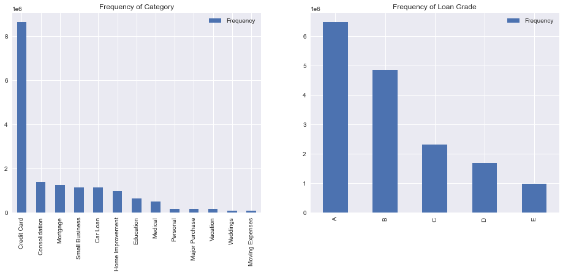

```python
## DataFrame of the Category rows
categorydf = (freq_df
              .query('Column == "Category"')
              .sort_values('Frequency', ascending = False))

## DataFrame of the LoanGrade rows
loanGradedf = (freq_df
               .query('Column == "LoanGrade"')
               .sort_values('Frequency', ascending = False))

## Display the DataFrames
display(categorydf, loanGradedf)


##
## Plot the SASDataFrames
##
fig, (ax1, ax2) = plt.subplots(ncols = 2, figsize = (16,6))

## ax1
categorydf.plot(kind = 'bar', x = 'CharVar', y = 'Frequency',
                ax = ax1, title = "Frequency of Category", xlabel = '')

## ax2
loanGradedf.plot(kind = 'bar', x = 'CharVar', y = 'Frequency',
                 ax = ax2, title = "Frequency of Loan Grade",  xlabel = '');
```

d. You can also create a calculated column for ad hoc analysis in an action or method by adding the computedVarsProgram parameter to the **CASTable** object. Here, a new column is created named **InterestCat**. It uses the SAS IFC function to create a new column based on conditions. If the current value of **InterestRate** is *0*, then there was *No Interest*. Otherwise, the value is *Interest*. Then use the **tbl** object with the freq action. Specify the inputs parameter with the new **InterestCat** column.

```python
## Create a new column
tbl.computedVarsProgram = "InterestCat = ifc(InterestRate = 0, 'No Interest', 'Interest');"
display(tbl)

## Analyze the new column
cr_freq = tbl.freq(inputs='InterestCat')
display(cr_freq)

## Delete the computedVarsProgram parameter
del tbl.computedVarsProgram
display(tbl)
```

```
CASTable('loans_raw', caslib='casuser', computedvarsprogram="InterestCat = ifc(InterestRate = 0, 'No Interest', 'Interest');")
```

**§ Frequency**

Frequency for LOANS_RAW

|  | Column | CharVar | FmtVar | Level | Frequency |
| --- | --- | --- | --- | --- | --- |
| 0 | InterestCat | Interest | Interest | 1 | 16017463.0 |
| 1 | InterestCat | No Interest | No Interest | 2 | 293584.0 |

elapsed 6.39s · user 30.2s · sys 6.32s · mem 3.12e+03MB

```
CASTable('loans_raw', caslib='casuser')
```

### 5. Frequency Distribution Using the freqTab Action

a. The [freqTab.freqTab](https://go.documentation.sas.com/doc/en/pgmsascdc/v_017/casactstat/cas-freqtab-TblOfActions.htm?homeOnFail) action provides much more functionality than the freq action. To use the freqTab action set, you first need to load the freqTab action set using the [builtins.loadActionSet](https://go.documentation.sas.com/doc/en/pgmsascdc/v_017/caspg/cas-builtins-loadactionset.htm) action.

```python
conn.loadActionSet('freqtab')
```

```
NOTE: Added action set 'freqtab'.
```

**§ actionset**

freqtab

elapsed 0.238s · user 0.00328s · sys 0.00527s · mem 0.237MB

b. Use the freqTab action to create a simple one-way frequency table similar to the freq action. Begin by creating a frequency table of the **Category** column by using the tabulate parameter. Notice that the results of the freqTab action return a variety of information such as the level information, number of observations, the one-way frequency table, and timing.

```python
ft_cr = tbl.freqTab(tabulate = 'Category')
ft_cr
```

**§ LevelInfo**

Variable Level Information

|  | Variable | Levels | Values |
| --- | --- | --- | --- |
| 0 | Category | 13 | Car Loan Consolidation Credit Card Education H... |

**§ NObs**

Number of Observations

|  | RowId | Description | Value |
| --- | --- | --- | --- |
| 0 | NREAD | Number of Observations Read | 16311047.0 |
| 1 | NUSED | Number of Observations Used | 16311047.0 |
| 2 | NWEIGHTS | Sum of Weights | 16311047.0 |

**§ Table1.OneWayFreqs**

Category

|  | F_Category | Category | Frequency | Percent | CumFrequency | CumPercent |
| --- | --- | --- | --- | --- | --- | --- |
| 0 | Car Loan | Car Loan | 1137900.0 | 6.976254 | 1137900.0 | 6.976254 |
| 1 | Consolidation | Consolidation | 1388803.0 | 8.514493 | 2526703.0 | 15.490747 |
| 2 | Credit Card | Credit Card | 8634724.0 | 52.937889 | 11161427.0 | 68.428636 |
| 3 | Education | Education | 651562.0 | 3.994606 | 11812989.0 | 72.423242 |
| 4 | Home Improvement | Home Improvement | 976724.0 | 5.988113 | 12789713.0 | 78.411355 |
| 5 | Major Purchase | Major Purchase | 162736.0 | 0.997704 | 12952449.0 | 79.409059 |
| 6 | Medical | Medical | 488401.0 | 2.994296 | 13440850.0 | 82.403355 |
| 7 | Mortgage | Mortgage | 1243328.0 | 7.622613 | 14684178.0 | 90.025968 |
| 8 | Moving Expenses | Moving Expenses | 81087.0 | 0.497129 | 14765265.0 | 90.523098 |
| 9 | Personal | Personal | 163713.0 | 1.003694 | 14928978.0 | 91.526792 |
| 10 | Small Business | Small Business | 1138260.0 | 6.978461 | 16067238.0 | 98.505252 |
| 11 | Vacation | Vacation | 162388.0 | 0.995571 | 16229626.0 | 99.500823 |
| 12 | Weddings | Weddings | 81421.0 | 0.499177 | 16311047.0 | 100.000000 |

**§ Timing**

Task Timing

|  | Task | Time | RelTime |
| --- | --- | --- | --- |
| 0 | Setup and Parsing | 0.013221 | 0.005472 |
| 1 | Levelization | 1.579564 | 0.653806 |
| 2 | Producing Results Tables | 0.823160 | 0.340718 |
| 3 | Cleanup | 0.000008 | 0.000003 |
| 4 | Total | 2.415953 | 1.000000 |

elapsed 2.43s · user 26.4s · sys 0.0882s · mem 4.64MB

c. View the keys of the **CASResults** object using the keys method. You see that four keys exist in the **CASResults** object.

```python
ft_cr.keys()
```

```
odict_keys(['LevelInfo', 'NObs', 'Table1.OneWayFreqs', 'Timing'])
```

d. To visualize the one-way frequency table, call the *Table1.OneWayFreqs* key to return the **SASDataFrame**. Then use Pandas to sort and plot the **SASDataFrame**.

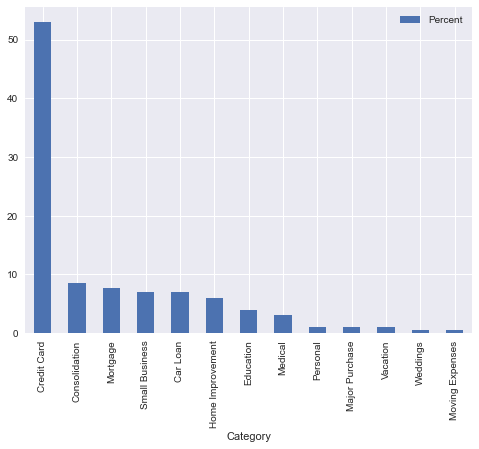

```python
## Store the SASDataFrame from the CASResults objects
freq_df = ft_cr['Table1.OneWayFreqs']

## Process the SASDataFrame using Pandas
(freq_df
 .sort_values('Percent', ascending = False)
 .plot(kind='bar', x = 'Category', y = 'Percent', figsize = (8,6)));
```

e. The freqTab action enables you to create as many frequency and crosstabulation tables as you would like within a single action by specifying a list in the tabulate parameter. Here, the freqTab action creates a one-way frequency table for **Category** and **LoanGrade**, and a crosstabulation of **Category** and **LoanGrade**. Store the results in the **ft** variable and display the results.

**Note**: To create crosstabulation, tables you specify a list with a dictionary within the tabulate parameter. Use the key *vars*, followed by a list of columns to use for the crosstabulation table.

```python
ft = tbl.freqTab(tabulate = [
                   'Category',
                   'LoanGrade',
                   {'vars' : ['Category','LoanGrade']},
                ])

display(ft)
```

**§ LevelInfo**

Variable Level Information

|  | Variable | Levels | Values |
| --- | --- | --- | --- |
| 0 | Category | 13 | Car Loan Consolidation Credit Card Education H... |
| 1 | LoanGrade | 5 | A B C D E |

**§ NObs**

Number of Observations

|  | RowId | Description | Value |
| --- | --- | --- | --- |
| 0 | NREAD | Number of Observations Read | 16311047.0 |
| 1 | NUSED | Number of Observations Used | 16311047.0 |
| 2 | NWEIGHTS | Sum of Weights | 16311047.0 |

**§ Table1.OneWayFreqs**

Category

|  | F_Category | Category | Frequency | Percent | CumFrequency | CumPercent |
| --- | --- | --- | --- | --- | --- | --- |
| 0 | Car Loan | Car Loan | 1137900.0 | 6.976254 | 1137900.0 | 6.976254 |
| 1 | Consolidation | Consolidation | 1388803.0 | 8.514493 | 2526703.0 | 15.490747 |
| 2 | Credit Card | Credit Card | 8634724.0 | 52.937889 | 11161427.0 | 68.428636 |
| 3 | Education | Education | 651562.0 | 3.994606 | 11812989.0 | 72.423242 |
| 4 | Home Improvement | Home Improvement | 976724.0 | 5.988113 | 12789713.0 | 78.411355 |
| 5 | Major Purchase | Major Purchase | 162736.0 | 0.997704 | 12952449.0 | 79.409059 |
| 6 | Medical | Medical | 488401.0 | 2.994296 | 13440850.0 | 82.403355 |
| 7 | Mortgage | Mortgage | 1243328.0 | 7.622613 | 14684178.0 | 90.025968 |
| 8 | Moving Expenses | Moving Expenses | 81087.0 | 0.497129 | 14765265.0 | 90.523098 |
| 9 | Personal | Personal | 163713.0 | 1.003694 | 14928978.0 | 91.526792 |
| 10 | Small Business | Small Business | 1138260.0 | 6.978461 | 16067238.0 | 98.505252 |
| 11 | Vacation | Vacation | 162388.0 | 0.995571 | 16229626.0 | 99.500823 |
| 12 | Weddings | Weddings | 81421.0 | 0.499177 | 16311047.0 | 100.000000 |

**§ Table2.OneWayFreqs**

LoanGrade

|  | F_LoanGrade | LoanGrade | Frequency | Percent | CumFrequency | CumPercent |
| --- | --- | --- | --- | --- | --- | --- |
| 0 | A | A | 6474094.0 | 39.691468 | 6474094.0 | 39.691468 |
| 1 | B | B | 4851393.0 | 29.742990 | 11325487.0 | 69.434458 |
| 2 | C | C | 2323415.0 | 14.244426 | 13648902.0 | 83.678883 |
| 3 | D | D | 1690548.0 | 10.364436 | 15339450.0 | 94.043319 |
| 4 | E | E | 971597.0 | 5.956681 | 16311047.0 | 100.000000 |

**§ Table3.CrossList**

Table of Category by LoanGrade

|  | F_Category | Category | F_LoanGrade | LoanGrade | Frequency | Percent | RowPercent | ColPercent |
| --- | --- | --- | --- | --- | --- | --- | --- | --- |
| 0 | Car Loan | Car Loan | A | A | 452115.0 | 2.771833 | 39.732402 | 6.983448 |
| 1 | Car Loan | Car Loan | B | B | 338291.0 | 2.073999 | 29.729414 | 6.973069 |
| 2 | Car Loan | Car Loan | C | C | 161552.0 | 0.990445 | 14.197381 | 6.953213 |
| 3 | Car Loan | Car Loan | D | D | 118142.0 | 0.724307 | 10.382459 | 6.988385 |
| 4 | Car Loan | Car Loan | E | E | 67800.0 | 0.415669 | 5.958344 | 6.978202 |
| ... | ... | ... | ... | ... | ... | ... | ... | ... |
| 79 | Total |  | B | B | 4851393.0 | 29.742990 | NaN | 100.000000 |
| 80 | Total |  | C | C | 2323415.0 | 14.244426 | NaN | 100.000000 |
| 81 | Total |  | D | D | 1690548.0 | 10.364436 | NaN | 100.000000 |
| 82 | Total |  | E | E | 971597.0 | 5.956681 | NaN | 100.000000 |
| 83 | Total |  | Total |  | 16311047.0 | 100.000000 | NaN | NaN |

84 rows × 8 columns

**§ Timing**

Task Timing

|  | Task | Time | RelTime |
| --- | --- | --- | --- |
| 0 | Setup and Parsing | 0.006444 | 0.002137 |
| 1 | Levelization | 1.812964 | 0.601275 |
| 2 | Producing Results Tables | 1.195787 | 0.396586 |
| 3 | Cleanup | 0.000007 | 0.000002 |
| 4 | Total | 3.015202 | 1.000000 |

elapsed 3.02s · user 35s · sys 0.0634s · mem 4.74MB

f. To view the first 15 rows of the crosstabulation, call the *Table3.CrossList* key from the **CASResults** object to store the **SASDataFrame**. Then execute the head method.

```python
ft['Table3.CrossList'].head(15)
```

Table of Category by LoanGrade

|  | F_Category | Category | F_LoanGrade | LoanGrade | Frequency | Percent | RowPercent | ColPercent |
| --- | --- | --- | --- | --- | --- | --- | --- | --- |
| 0 | Car Loan | Car Loan | A | A | 452115.0 | 2.771833 | 39.732402 | 6.983448 |
| 1 | Car Loan | Car Loan | B | B | 338291.0 | 2.073999 | 29.729414 | 6.973069 |
| 2 | Car Loan | Car Loan | C | C | 161552.0 | 0.990445 | 14.197381 | 6.953213 |
| 3 | Car Loan | Car Loan | D | D | 118142.0 | 0.724307 | 10.382459 | 6.988385 |
| 4 | Car Loan | Car Loan | E | E | 67800.0 | 0.415669 | 5.958344 | 6.978202 |
| 5 | Car Loan | Car Loan | Total |  | 1137900.0 | 6.976254 | 100.000000 | NaN |
| 6 | Consolidation | Consolidation | A | A | 551865.0 | 3.383382 | 39.736737 | 8.524204 |
| 7 | Consolidation | Consolidation | B | B | 413927.0 | 2.537710 | 29.804587 | 8.532127 |
| 8 | Consolidation | Consolidation | C | C | 197186.0 | 1.208911 | 14.198270 | 8.486904 |
| 9 | Consolidation | Consolidation | D | D | 143297.0 | 0.878527 | 10.318022 | 8.476364 |
| 10 | Consolidation | Consolidation | E | E | 82528.0 | 0.505964 | 5.942383 | 8.494057 |
| 11 | Consolidation | Consolidation | Total |  | 1388803.0 | 8.514493 | 100.000000 | NaN |
| 12 | Credit Card | Credit Card | A | A | 3426633.0 | 21.008051 | 39.684337 | 52.928379 |
| 13 | Credit Card | Credit Card | B | B | 2567024.0 | 15.737947 | 29.729080 | 52.913132 |
| 14 | Credit Card | Credit Card | C | C | 1230749.0 | 7.545494 | 14.253484 | 52.971553 |

### 6. Creating Crosstabs Using the crossTab Action

a. The [simple.crossTab](https://go.documentation.sas.com/doc/en/pgmsascdc/v_017/casanpg/cas-simple-crosstab.htm) action performs a one-way or two-way tabulation. Here, the crossTab action creates a two-way tabulation between **Category** and **LoanGrade**. Use the row parameter to specify the row, and the col parameter to specify the column. Store the **SASDataFrame** from the result of the crossTab action in the variable **cross_df** and view the results. Notice that the results of the crossTab action do not name the columns by default.

```python
cross_df = tbl.crosstab(row = 'Category', col = 'LoanGrade')['Crosstab']
cross_df
```

|  | Category | Col1 | Col2 | Col3 | Col4 | Col5 |
| --- | --- | --- | --- | --- | --- | --- |
| 0 | Car Loan | 452115.0 | 338291.0 | 161552.0 | 118142.0 | 67800.0 |
| 1 | Consolidation | 551865.0 | 413927.0 | 197186.0 | 143297.0 | 82528.0 |
| 2 | Credit Card | 3426633.0 | 2567024.0 | 1230749.0 | 895762.0 | 514556.0 |
| 3 | Education | 258489.0 | 193935.0 | 92751.0 | 67426.0 | 38961.0 |
| 4 | Home Improvement | 387014.0 | 290152.0 | 139406.0 | 101832.0 | 58320.0 |
| 5 | Major Purchase | 64623.0 | 48167.0 | 23226.0 | 16974.0 | 9746.0 |
| 6 | Medical | 193925.0 | 145654.0 | 69432.0 | 50249.0 | 29141.0 |
| 7 | Mortgage | 493851.0 | 370156.0 | 177069.0 | 128599.0 | 73653.0 |
| 8 | Moving Expenses | 32005.0 | 24419.0 | 11457.0 | 8403.0 | 4803.0 |
| 9 | Personal | 65264.0 | 48528.0 | 23215.0 | 16948.0 | 9758.0 |
| 10 | Small Business | 451589.0 | 338542.0 | 162604.0 | 117844.0 | 67681.0 |
| 11 | Vacation | 64353.0 | 48363.0 | 23315.0 | 16684.0 | 9673.0 |
| 12 | Weddings | 32368.0 | 24235.0 | 11453.0 | 8388.0 | 4977.0 |

b. A **SASDataFrame** contains a variety of additional attributes and methods. One useful attribute is the colInfo attribute. It enables you to view column information of the **SASDataFrame** like the column name, labels and data type. When you execute the colInfo attribute, notice that the *label* key of each column contains the **LoanGrade** value. You can use this information to rename the default column names of the crossTab action.

```python
## View the SASDataFrame column attributes. This is an additional attribute available with SASDataFrames
cross_df.colinfo
```

```
{'Category': SASColumnSpec(attrs=dict(Template='Row'), dtype='varchar', name='Category', size=(1, 1), width=16),
 'Col1': SASColumnSpec(attrs=dict(Template='Col'), dtype='double', label='A', name='Col1', size=(1, 1), width=8),
 'Col2': SASColumnSpec(attrs=dict(Template='Col'), dtype='double', label='B', name='Col2', size=(1, 1), width=8),
 'Col3': SASColumnSpec(attrs=dict(Template='Col'), dtype='double', label='C', name='Col3', size=(1, 1), width=8),
 'Col4': SASColumnSpec(attrs=dict(Template='Col'), dtype='double', label='D', name='Col4', size=(1, 1), width=8),
 'Col5': SASColumnSpec(attrs=dict(Template='Col'), dtype='double', label='E', name='Col5', size=(1, 1), width=8)}
```

c. You can use the apply_labels method with the inplace equals *True* parameter to apply the column labels as the column names. Execute the cell and notice that the column names have changed.

```python
## Apply the labels of the SASDataFrame as the column names
cross_df.apply_labels(inplace = True)
cross_df
```

|  | Category | A | B | C | D | E |
| --- | --- | --- | --- | --- | --- | --- |
| 0 | Car Loan | 452115.0 | 338291.0 | 161552.0 | 118142.0 | 67800.0 |
| 1 | Consolidation | 551865.0 | 413927.0 | 197186.0 | 143297.0 | 82528.0 |
| 2 | Credit Card | 3426633.0 | 2567024.0 | 1230749.0 | 895762.0 | 514556.0 |
| 3 | Education | 258489.0 | 193935.0 | 92751.0 | 67426.0 | 38961.0 |
| 4 | Home Improvement | 387014.0 | 290152.0 | 139406.0 | 101832.0 | 58320.0 |
| 5 | Major Purchase | 64623.0 | 48167.0 | 23226.0 | 16974.0 | 9746.0 |
| 6 | Medical | 193925.0 | 145654.0 | 69432.0 | 50249.0 | 29141.0 |
| 7 | Mortgage | 493851.0 | 370156.0 | 177069.0 | 128599.0 | 73653.0 |
| 8 | Moving Expenses | 32005.0 | 24419.0 | 11457.0 | 8403.0 | 4803.0 |
| 9 | Personal | 65264.0 | 48528.0 | 23215.0 | 16948.0 | 9758.0 |
| 10 | Small Business | 451589.0 | 338542.0 | 162604.0 | 117844.0 | 67681.0 |
| 11 | Vacation | 64353.0 | 48363.0 | 23315.0 | 16684.0 | 9673.0 |
| 12 | Weddings | 32368.0 | 24235.0 | 11453.0 | 8388.0 | 4977.0 |

d. In the crossTab action, you can add the aggregator and weight parameters to summarize the data. Here, the mean **InterestRate** is calculated for each **Category** by **LoanGrade**. Then rename the default columns using the apply_labels method.

```python
## Summarize the data in CAS
cross_df = tbl.crosstab(row = 'Category',
                        col = 'LoanGrade',
                        aggregator = 'MEAN',
                        weight = 'InterestRate')['Crosstab']


## Rename the columns with the labels
cross_df.apply_labels(inplace = True)
cross_df
```

|  | Category | A | B | C | D | E |
| --- | --- | --- | --- | --- | --- | --- |
| 0 | Car Loan | 4.158283 | 4.649605 | 5.382396 | 6.058592 | 6.288695 |
| 1 | Consolidation | 5.940019 | 6.642388 | 7.690280 | 8.153265 | 8.385097 |
| 2 | Credit Card | 15.051902 | 16.820594 | 19.477458 | 18.867591 | 19.104955 |
| 3 | Education | 5.542521 | 6.192829 | 7.175130 | 7.683690 | 7.925139 |
| 4 | Home Improvement | 8.306218 | 9.294619 | 10.770422 | 10.585254 | 10.743045 |
| 5 | Major Purchase | 11.897985 | 13.281976 | 15.404970 | 15.155748 | 15.339844 |
| 6 | Medical | 6.337595 | 7.086438 | 8.201472 | 8.622016 | 8.850593 |
| 7 | Mortgage | 3.564140 | 3.985277 | 4.616193 | 5.358222 | 5.590587 |
| 8 | Moving Expenses | 11.881171 | 13.256937 | 15.389410 | 15.192644 | 15.378561 |
| 9 | Personal | 11.890843 | 13.278956 | 15.363515 | 15.143307 | 15.408861 |
| 10 | Small Business | 7.921296 | 8.850410 | 10.247131 | 10.478789 | 10.702184 |
| 11 | Vacation | 11.906484 | 13.283578 | 15.421903 | 15.117363 | 15.360789 |
| 12 | Weddings | 11.884211 | 13.289195 | 15.347799 | 15.109485 | 15.348228 |

### 7. Terminate the CAS Session

It's best practice to always terminate the CAS session when you are done.

```python
conn.terminate()
```